# Tarea3_Ricardo_Garbanzo

Ricardo Garbanzo

13/2/2020

## 1. Utilizando el archivo 2019-ncov-confirmed.csv con informacion de los casos confirmados de la sepa de coronavirus 2019-nCoV la cual contiene las siguiente variables: region : indica si el infectado se encuentra en China o en otra region. date : fecha de la observacion. value: cantidad de casos confirmados. Realice lo siguiente:

### A) Lea los datos utilizando la siguiente instruccion (verifique que tenga instalado el paquete lubridate)

```r
library(lubridate)
datos <- read.csv("2019-ncov-confirmed.csv", header = T)
datos$fecha <- lubridate::ymd_hms(datos$fecha)
```

### B) Utilizando el paquete ggplot2 realice un grafico de lineas que represente la cantidad de casos conformados diferenciando entre los casos reportados en China y los casos reportados en otras regiones, agregue los titulos y legendas requeridas y coloque como fuente de los datos a la Universidad Johns Hopkins.

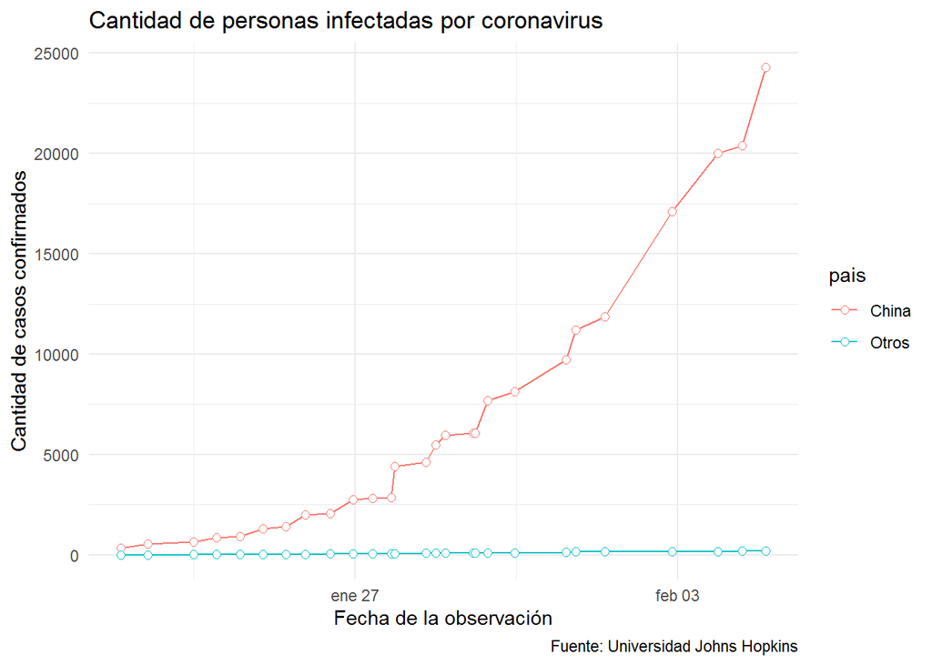

```r
library(ggplot2)
library(scales)
ggplot(datos, aes(x=fecha, y=infectados, colour = pais )) +
  geom_line()  +
  geom_point( size=2, shape=21, fill="white") +
  theme_minimal()+
  labs(title = "Cantidad de personas infectadas por coronavirus ",
       x = "Fecha de la observación",
       y = "Cantidad de casos confirmados",
       caption = "Fuente: Universidad Johns Hopkins")
```

### C) Utilizando el paquete apexcharter repite el grafico del punto anterior.

```r
library(apexcharter)

apex(data = datos,
     type = "line",
     mapping = aes(x = fecha,
                   y = infectados, fill = pais)) %>%
  ax_title(text = "Cantidad de personas infectadas por coronavirus ",
           style = list(fontSize = 20),
           align = "center") %>%
ax_labs(       x = "Fecha de la observación",
       y = "Cantidad de casos confirmados")
```

[interactive chart not shown]

## 2. Utilizando los datos de la tabla 2019-ncov-total.csv realice lo siguiente:

### a) Instale los paquetes rnaturalearth y rnaturalearthdata, estos le permitiran cargar los datos para realizar un grafico del mundo.

### b) Cargue el los datos de todos los paises utilizando la siguiente instruccion. world <- ne_ countries ( scale = " small “, returnclass =”sf")

### c) Agregue a la tabla world una variable que le permita saber cuales paises tienen o no casos confirmados de 2019-nCoV.

### d) Utilizando los paquetes sf, ggforce y ggplot2 replique el siguiente grafico.

```r
library(tidyverse)
library(sf)
```

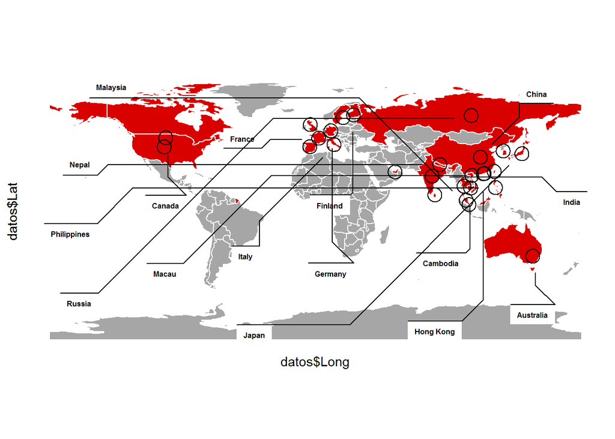

```r
library(rnaturalearth)
library(rnaturalearthdata)
library(ggforce)
library(ggplot2)
world <- ne_countries(scale = "small", returnclass = "sf")
datos <- read.csv("2019-ncov-total.csv", header = T)


world_infectados <- left_join(x = world,
                              y = datos,
                              by = c("admin" = "region"))
ggplot(data = world)+
  geom_sf(color="white", fill= case_when(world_infectados$value >= 1 ~"#d90000", TRUE ~"#a6a6a6"))+
  theme_classic()+
  geom_mark_circle(data=datos,
                   mapping=aes(x=datos$Long,
                               y=datos$Lat,
                               group=datos$region,
                               label=datos$region),
                   expand = unit(2,"mm"),
                   label.fontsize = 6)
```

## 3. Utilizando el conjunto de datos “2019-ncov-totals-coords.csv” y el paquete leaflet genere un mapa interactivo que cumpla con los siguientes requisitos:

### a) Se debe colocar un marcador en cada uno de los paises que han reportado casos de 2019-nCoV.

### b) Al dar clic sobre un marcador se debe desplegar un mensaje que nos indique la ciudad y la cantidad de casos reportados.

```r
library(tidyverse)
library(sf)
library(rnaturalearth)
library(rnaturalearthdata)
library(ggforce)
library(ggplot2)
library(leaflet)
library(htmltools)
library(stringr)
library(scales)
library(purrr)


world <- ne_countries(scale = "small", returnclass = "sf")
datos <- read.csv("2019-ncov-totals-coords.csv", header = T)


world_infectados_interactivo <- right_join(x = world,y = datos, by = c("admin" = "region"))
pal <- colorBin("Reds", domain = world_infectados_interactivo$pop_est)

etiquetas <- map(transpose(world_infectados_interactivo), ~{
  HTML(
    str_c("<strong> País: ", .$admin, "</strong>",
          "<br/>",
          "Cantidad de infectados: ", comma(.$value))
  )
})


leaflet(world_infectados_interactivo) %>%
  addTiles() %>%
  addPolygons(label = ~etiquetas,
              fillColor = ~pal(pop_est),
              fillOpacity = .9,
              weight = 2.0,
              color = "black",
              highlightOptions = highlightOptions(color = "#ff935c",
                                                  weight = 3,
                                                  bringToFront = TRUE,
                                                  opacity = 1))
```

[interactive chart not shown]